# Abacavirinol

Joseph Nielsen

12/5/2018

# Introduction

A new preventative aides (abacavirinol) is under test in clinical trials. Analyze the effectiveness of this drug across the board. Consider population subgroups by gender, drug use, and sexual orientation. Finish this!

# Methods

We are running the data based on different groups; the whole, Drug users, male, female, and the LGBT. We want to see if the use of vaccines containing ALVAC-HIV and AIDSVAX B/E or, placebo-controlled is more useful in preventing aids. To do this we will run a series of test to come to a conclusion. We will look at a basic bar graph to see the information easily. Since we don’t want to base our conclusion on a basic bar graph we will run a basic numerical test. Then after all that we want to make sure we see all the information we run a chisqtest and a fisher.t test. Now we will do this for all the groups listed above to see if our conclusion that we got as a whole will apply to each subdivision, just because something seems like it works for the whole, it might not work for everyone.

### Everyone

## Results

This is the results we got for the whole, we have two subdivisions for the results. First the graphical data containing a bar graph. Then the numerical data where we have the basic numerical data and some more advanced inferential data I.E a chisqtest and a fisher.t test.

## Descriptive Results

### Graphical Descriptive Results

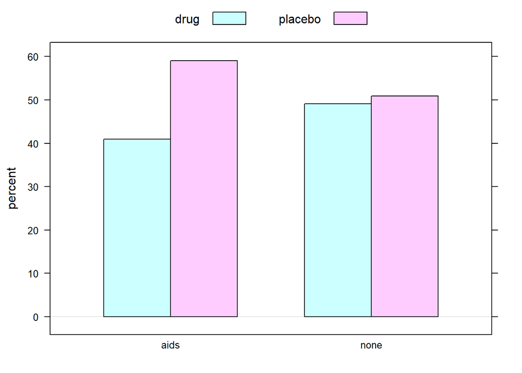

```r
results<- xtabs(~infected+treatment,data=abac)
barchartGC(results,type = "percent")
```

Based on this graph there is a lot less people who took the drug and have aids. The highest percentage of people who have aids took the placebo. While the people who dont have aids is about even for the drug versus the placebo.

### Numerical Descriptive Results

```r
colPerc(results)
```

```
##         treatment
## infected   drug placebo
##    aids    4.04    5.54
##    none   95.96   94.46
##    Total 100.00  100.00
```

```r
rowPerc(results)
```

```
##         treatment
## infected   drug placebo  Total
##     aids  40.93   59.07 100.00
##     none  49.10   50.90 100.00
```

According to these statstical results from colperc it shows that 4.04% that took the drug ended up with aids, while 95.96% didn’t. Then 5.54% who took the placebo ended up with aids while 94.46% didnt. Then in the rowperc test it shows that 40.93% of people with aids took the drug while 59.07% of people took the placebo. Then 49.10% of people who dont have aids took the drug while 50.9% took the placebo.

## Inferential Results

```
## Pearson's Chi-squared test with Yates' continuity correction
##
## Observed Counts:
##         treatment
## infected drug placebo
##     aids   97     140
##     none 2303    2387
##
## Counts Expected by Null:
##         treatment
## infected    drug placebo
##     aids  115.45  121.55
##     none 2284.55 2405.45
##
## Contributions to the chi-square statistic:
##         treatment
## infected drug placebo
##     aids 2.95    2.80
##     none 0.15    0.14
##
##
## Chi-Square Statistic = 5.7138
## Degrees of Freedom of the table = 1
## P-Value = 0.0168
```

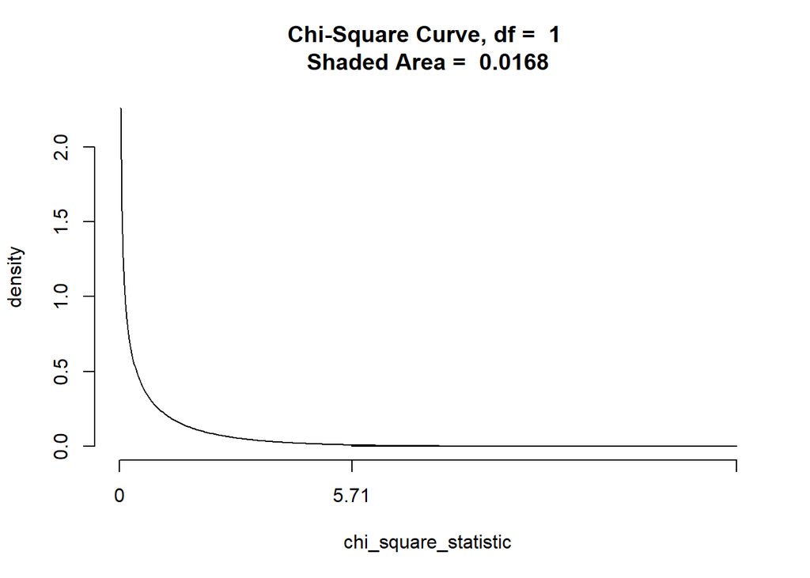

```r
chisqtestGC(results, graph = TRUE)
```

```r
fisher.test(results)
```

```
##
##  Fisher's Exact Test for Count Data
##
## data:  results
## p-value = 0.01634
## alternative hypothesis: true odds ratio is not equal to 1
## 95 percent confidence interval:
##  0.5449798 0.9433871
## sample estimates:
## odds ratio
##  0.7181794
```

According to the chi-squared test it shows that 97 people who took the drug ended up with aids while 2303 did not have aids. Then 140 people who took the placebo ended up with aids while 2387 did not. The chi-squared test also gave us a p-value of 0.0168 which is enough to reject the null hypothesis. Although, we want to make sure of the p-value so that’s where the fisher test come in and gives us a p-value of 0.0163 which means we can reject the null hypothesis.

# Discussion and Conclusion

## Drug Users

# Results

This is the results we got for the drug users, we have two subdivisions for the results. First the graphical data containing a bar graph. Then the numerical data where we have the basic numerical data and some more advanced inferential data I.E a chisqtest and a fisher.t test.

## Descriptive Results

### Graphical Descriptive Results

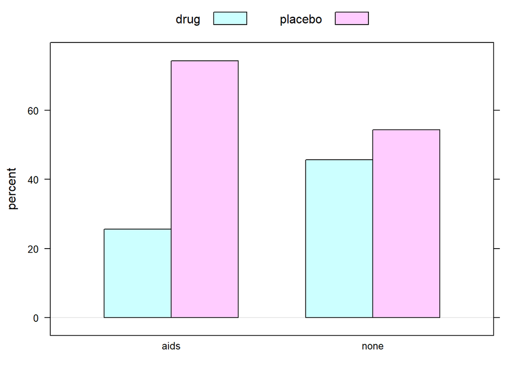

```r
resultsDrug<- xtabs(~infected+treatment,data=drugs)
barchartGC(resultsDrug,type = "percent")
```

### Numerical Descriptive Results

```r
colPerc(resultsDrug)
```

```
##         treatment
## infected   drug placebo
##    aids    3.17     7.4
##    none   96.83    92.6
##    Total 100.00   100.0
```

```r
rowPerc(resultsDrug)
```

```
##         treatment
## infected   drug placebo  Total
##     aids  25.64   74.36 100.00
##     none  45.66   54.34 100.00
```

According to these statstical results from colperc it shows that 3.17% that took the drug ended up with aids, while 96.83% didn’t. Then 7.4% who took the placebo ended up with aids while 92.6% didnt. Then in the rowperc test it shows that 25.64% of people with aids took the drug while 74.36% of people took the placebo. Then 45.66% of people who dont have aids took the drug while 54.34% took the placebo.

## Inferential Results

```
## Pearson's Chi-squared test with Yates' continuity correction
##
## Observed Counts:
##         treatment
## infected drug placebo
##     aids   10      29
##     none  305     363
##
## Counts Expected by Null:
##         treatment
## infected   drug placebo
##     aids  17.38   21.62
##     none 297.62  370.38
##
## Contributions to the chi-square statistic:
##         treatment
## infected drug placebo
##     aids 3.13    2.52
##     none 0.18    0.15
##
##
## Chi-Square Statistic = 5.1942
## Degrees of Freedom of the table = 1
## P-Value = 0.0227
```

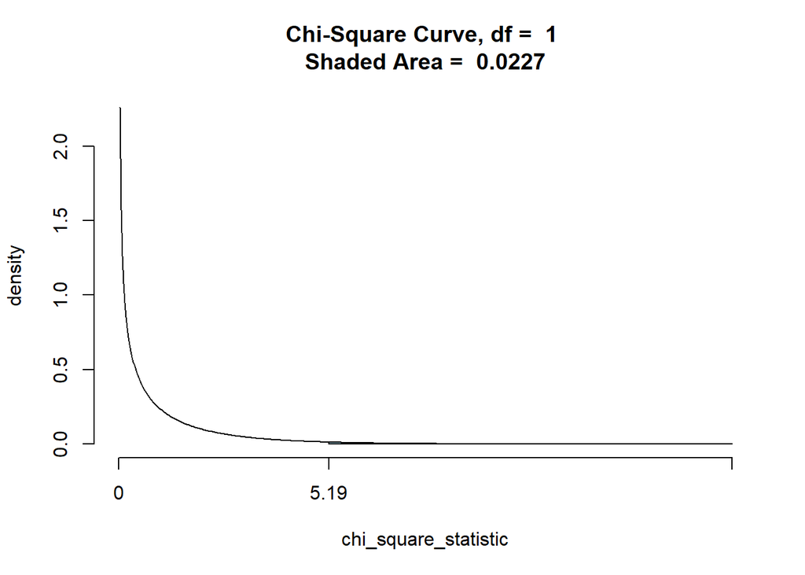

```r
chisqtestGC(resultsDrug, graph = TRUE)
```

```r
fisher.test(resultsDrug)
```

```
##
##  Fisher's Exact Test for Count Data
##
## data:  resultsDrug
## p-value = 0.01929
## alternative hypothesis: true odds ratio is not equal to 1
## 95 percent confidence interval:
##  0.1757111 0.8844152
## sample estimates:
## odds ratio
##  0.4108953
```

According to the chi-squared test it shows that 10 people who took the drug ended up with aids while 305 did not have aids. Then 29 people who took the placebo ended up with aids while 363 did not. The chi-squared test also gave us a p-value of 0.0227 which is enough to reject the null hypothesis. Although, we want to make sure of the p-value so that’s where the fisher test come in and gives us a p-value of 0.0192 which means we can reject the null hypothesis.